# INFLATION ANALYSIS IN THE US ECONOMY

2024-10-30

# What is inflation?

Inflation is the sustained increase in the general price level of goods and services over time. Typically measured using indices such as the Consumer Price Index (CPI) and the Producer Price Index (PPI). For my analysis, I’m focusing on CPI.

# What is CPI?

A consumer price index is a price index, the price of a weighted average market basket of consumer goods and services purchased by households. Changes in measured CPI track changes in prices over time. The CPI is calculated by using a representative basket of goods and services

```r
# Load required libraries
library(dplyr)
library(tidymodels)
library(forecast)
```

# Data Reading

```r
input_dir <- "C:\\Users\\prish\\OneDrive\\Desktop\\Lehigh\\Intro_to_statistical_modeling\\BandyopadhyayPrisha\\cpi_project_dataset.csv"
data <- read.csv(input_dir, header = T, sep = ",")
```

Splitting the sectors for better visualization

```r
# Define the sectors for Group 1
group1_sectors <- c("Food and beverages", "Apparel", "Alcoholic beverages")

# Split the data
group1 <- data %>% filter(TITLE %in% group1_sectors)
group2 <- data %>% filter(!(TITLE %in% group1_sectors))

# Reshaping Group 1 data to long format
group1_long <- group1 %>%
  pivot_longer(cols = JAN:DEC, names_to = "Month", values_to = "Value")

# Reshaping Group 1 data to long format
group2_long <- group2 %>%
  pivot_longer(cols = JAN:DEC, names_to = "Month", values_to = "Value")
```

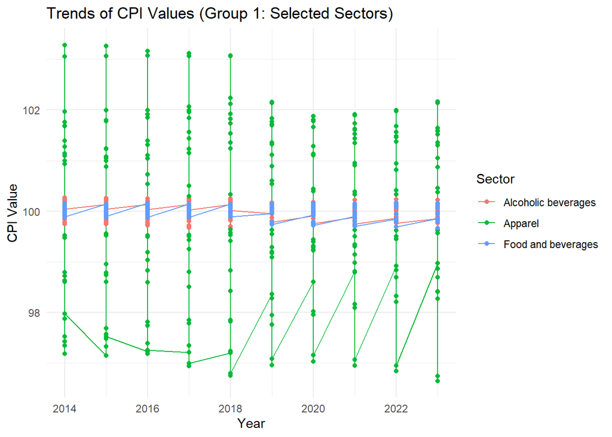

```r
# Plotting trends for Group 1
trends_group1 <- ggplot(group1_long, aes(x = YEAR, y = Value, color = TITLE, group = TITLE)) +
  geom_line() +
  geom_point() +
  labs(title = "Trends of CPI Values (Group 1: Selected Sectors)",
       x = "Year", y = "CPI Value", color = "Sector") +
  theme_minimal() +
  theme(legend.position = "right")
trends_group1
```

# Trends of CPI Values (Group 1: Selected Sectors)

1. Observations:
- Steady Trends: The sectors “Alcoholic beverages” and “Food and Beverages” exhibit relatively stable CPI trends over the years, with minor fluctuations. -“Apparel” Sector: This sector shows more variability, with periodic dips and recoveries. The broader range of points in some years might indicate seasonal fluctuations or specific shocks affecting food prices.
- Sector Comparison: “Apparel” has a noticeably larger spread of CPI values across months in each year compared to “Alcoholic beverages” and “Food and Beverages”. “Food and Beverages” appears to have the most consistent CPI values, suggesting a more stable price structure over time.
2. Insights:
- Stability in “Food and Beverages” and “Alcoholic beverages” could be due to predictable production and consumption patterns.
- “Apparel” is likely affected by external factors like weather conditions, supply chain issues, or demand surges.

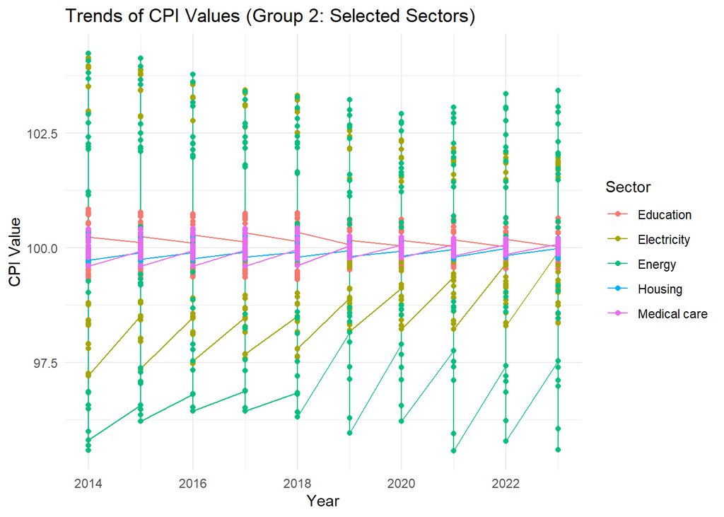

```r
# Plotting trends for Group 2
trends_group2 <- ggplot(group2_long, aes(x = YEAR, y = Value, color = TITLE, group = TITLE)) +
  geom_line() +
  geom_point() +
  labs(title = "Trends of CPI Values (Group 2: Selected Sectors)",
       x = "Year", y = "CPI Value", color = "Sector") +
  theme_minimal() +
  theme(legend.position = "right")
trends_group2
```

# Trends of CPI Values (Group 2: Other Sectors)

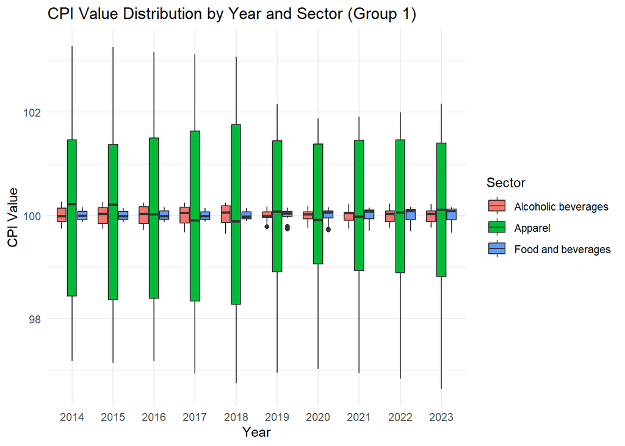

```r
# Boxplot for Group 1
boxplot_group1 <- ggplot(group1_long, aes(x = as.factor(YEAR), y = Value, fill = TITLE)) +
  geom_boxplot() +
  labs(title = "CPI Value Distribution by Year and Sector (Group 1)",
       x = "Year", y = "CPI Value", fill = "Sector") +
  theme_minimal()
boxplot_group1
```